# Percepción de la Gestión Institucional Preventiva

Propiedades psicométricas y distribución del constructo PGIP en apoderados de establecimientos educacionales chilenos

Bianca Bruna · Cristian Olate · Carlos Pizarro

2026-07-21

El problema

Los colegios *actúan*. Las familias no siempre lo *perciben*.

La violencia escolar no se combate únicamente reaccionando a incidentes, sino gestionando un **clima escolar preventivo**: cuando la familia no percibe ni se involucra en las acciones del colegio, la eficacia de estas se reduce y los esfuerzos dejan de ser consistentes. Medir esta **percepción** es clave para la alianza “escuela-familia”, además de identificar si los esfuerzos de los colegios son consistentes o equitativos a través de diversos contextos del país.

N = 178.266 padres, madres y apoderados evaluados en el proceso Simce 2024

178.266

## Objetivo general y específicos

**Analizar las propiedades psicométricas y la distribución de la Percepción de la Gestión Institucional Preventiva (PGIP)** en padres y apoderados de establecimientos educacionales chilenos.

01 Validar estructura interna y consistencia del constructo. → TCT · AFC

02 Caracterizar la percepción según variables de contexto. → Control sociodemográfico

03 Identificar sesgos y comportamientos de los ítems. → Análisis de ítems

04 Generar una métrica de puntuación escalar para el PGIP. → Puntuación 0–100

## 01 · Fundamentos · Antecedentes y Marco TeóricoGénesis teórica

Teoría Ecológica (Mesosistema) Bronfenbrenner, 1986 La interacción familia-escuela es la base para medir la salud de la alianza institucional.

Percepción Parental de Seguridad Astor y Benbenishty, 2019 Actúa como mediador clave entre los eventos reales de violencia y el involucramiento familiar.

Gestión Institucional Preventiva Carbajal, 2013 · Garcés, 2020 Transición del “control de conductas agresivas” hacia un modelo sistemático y proactivo que procura el bienestar de la comunidad.

Justicia Procedimental Tyler, 2006 La confianza parental depende de procedimientos justos, consistentes y comunicados con transparencia.

Clima Nutritivo vs. Tóxico Arón y Milicic, 2017 Los climas nutritivos fomentan la resolución de conflictos; la invisibilización parental genera climas tóxicos.

## El modelo de esferas superpuestas

**Epstein et al. (2009)** postula una responsabilidad mutua entre escuelas, familias y comunidades, operacionalizada en 6 tipos de involucramiento — base de la mayoría de los ítems de percepción parental en sistemas de gran escala.

1. Crianza Apoyo a las familias para establecer entornos domésticos que fomenten el aprendizaje.

2. Comunicación Diseño de canales efectivos y bidireccionales sobre programas y el progreso del estudiante.

3. Voluntariado Organización de los padres para apoyar las actividades y funciones del establecimiento.

4. Aprendizaje en casa Orientaciones para que los padres ayuden con tareas y decisiones curriculares.

5. Toma de decisiones Inclusión de los padres en el gobierno escolar y en el desarrollo de líderes parentales.

6. Colaboración comunitaria Integración de recursos de la comunidad para fortalecer los programas de los estudiantes.

> La convivencia enseña, no es materia de decisión. La escuela propone y enseña a los alumnos y alumnas una manera de relacionarse. — Fernando Onetto (2002)

## Antecedentes teóricos

Perfil del apoderado **“Voces de los apoderados” (2018)** indica que no hay diferencias significativas en la percepción de seguridad entre padres biológicos y otros cuidadores — la visión de la gestión es una propiedad compartida del hogar.

Brechas por GSE Apoderados de GSE alto ejercen mayor escrutinio crítico (crianza concertada); el GSE bajo tiende a delegar la autoridad en la escuela  
(Cheung y Pomerantz, 2012 · Lareau, 2003).

Gradiente de valoración del clima Los establecimientos particulares pagados presentan mejores valoraciones, seguidos por subvencionados y municipales  
(Padilla y Rodríguez, 2019).

Brechas por zona geográfica Los apoderados rurales reportan mayor aprobación de la representatividad de sus organizaciones (82%) que los urbanos (74%)  
(ACE, 2018).

Religión Mayor confianza en la gestión de colegios religiosos y percepción de un control social más efectivo sobre la violencia  
(Coleman, 1987 · Xu & Spruyt, 2022).

Isomorfismo institucional La fuerte regulación estatal empuja a todos los colegios a estandarizar sus procedimientos preventivos  
(DiMaggio y Powell, 1983 · López et al., 2018).

El presente estudio explora si estas brechas globales persisten en la realidad nacional, bajo un marco normativo altamente estandarizado (Ley de Violencia Escolar, normativas de la Superintendencia).

## Definición del constructo e hipótesis

Definición constitutiva

La PGIP es la variable latente que representa la valoración subjetiva del apoderado sobre la capacidad proactiva, normativa y operativa del establecimiento para salvaguardar la integridad de los estudiantes y fomentar un clima de sana convivencia.

*No es una medida de “ausencia de violencia”, sino de “presencia de gestión” (ACE, 2024).*

Definición operacional

Se operacionaliza mediante una **escala de 6 indicadores** de frecuencia (Likert 1 a 4), donde un mayor puntaje indica una percepción más favorable de la gestión. Siguiendo a **Crocker y Algina (2008)**.

Hipótesis psicométrica Los 6 ítems convergen en un único factor latente (PGIP), con validez estructural (AFC) y adecuada consistencia interna.

Hipótesis descriptiva de brechas Existen diferencias significativas en el nivel medio del PGIP según GSE, dependencia administrativa, ruralidad y orientación religiosa.

## 02 · Método · Población, muestra y análisis de ítemsPoblación estudiada

Padres, madres y apoderados de estudiantes de **II Medio** en Chile, evaluados en el proceso Simce 2024.

Se ensambló (*merge*) usando el Rol Base de Datos (`rbd`) como llave primaria, uniendo tres fuentes:

1. **Cuestionario Apoderados** — ítems del constructo PGIP (`capod_p11_01` a `06`).
2. **Agencia de Calidad (ACE)** — GSE, Dependencia Administrativa, Ruralidad.
3. **Directorio Oficial Mineduc** — orientación religiosa del establecimiento.

171.797 casos válidos tras eliminar respuestas inválidas (99 o 0) — 3,63% del total

## Tabla 1 · Caracterización de la muestra

Método · Muestra

| Categoría | N | % |
| --- | --- | --- |
| DA |  |  |
| Particular subvencionado | 97184 | 56.6 |
| Municipal | 48018 | 28.0 |
| Particular pagado | 16570 | 9.6 |
| SLE | 10025 | 5.8 |
| GSE |  |  |
| Medio Bajo | 57322 | 33.4 |
| Bajo | 41088 | 23.9 |
| Medio | 39568 | 23.0 |
| Medio Alto | 17393 | 10.1 |
| Alto | 16426 | 9.6 |

| Categoría | N | % |
| --- | --- | --- |
| Orientacion |  |  |
| Laico | 96887 | 56.4 |
| Confesional/Religioso | 72475 | 42.2 |
| Sin información | 2435 | 1.4 |
| Parentesco |  |  |
| Madre | 138606 | 80.7 |
| Padre | 21714 | 12.6 |
| Otro familiar/Cuidador | 9272 | 5.4 |
| Sin información | 2205 | 1.3 |
| Ruralidad |  |  |
| Urbano | 166519 | 96.9 |
| Rural | 5278 | 3.1 |

## Cuadro 1 · Mapeo de ítems

Método · Instrumento

**¿Con qué frecuencia ocurre lo siguiente en este colegio?**

| Cód. | Afirmación del ítem | Faceta | Sustento teórico |
| --- | --- | --- | --- |
| p11_01 | Se organizan actividades de prevención de la violencia (escuelas para apoderados, charlas, talleres, campañas, etc.). | Proactiva | Carbajal 2013 · Garcés 2020 |
| p11_02 | Se comunican de forma clara los procedimientos para enfrentar situaciones de violencia escolar. | Procedimental | Tyler 2006 |
| p11_03 | Se realizan actividades para el crecimiento personal y social de los(as) estudiantes. | Formativa | Arón y Milicic 2017 |
| p11_04 | Se solicita la participación de las familias para prevenir la violencia escolar. | Colaborativa | Epstein 2009 |
| p11_05 | Los adultos toman acciones para que mi hijo(a) se sienta seguro(a). | Seguridad Física | Astor y Benbenishty 2019 |
| p11_06 | Le enseñan a mi hijo(a) valores como el respeto y la sana convivencia. | Normativo-Ética | Onetto 2002 |

## Posibles sesgos · Dimensión de respuesta

Los ítems evalúan percepciones subjetivas mediante escala Likert, susceptible a patrones de respuesta (Crocker y Algina, 2008):

1. **Deseabilidad Social Institucional** — sobre-reportar acciones positivas (especialmente en GSE altos).
2. **Sesgo de Referencia** — evaluación contra estándares propios del apoderado, no un criterio absoluto.
3. **Sesgo de Aquiescencia** — tendencia automática a estar de acuerdo.
4. **Efecto Halo** — contaminación por un atributo global del establecimiento  
   (ej. prestigio).
5. **Sesgo de Tendencia Central** — evitación de categorías extremas, reduciendo la varianza.
6. **Sesgo por Método Común** — todas las respuestas comparten apoderado, momento y formato (Podsakoff et al., 2003).

## Posibles sesgos · Información, muestreo y procesamiento

Más allá de la respuesta, influyen la **posición del apoderado** en el ecosistema escolar y la **captura de datos** de la ACE:

7. **Observación Indirecta** — los padres no son testigos directos; dependen del relato del hijo(a) o la comunicación formal del colegio.
8. **Autoselección (no respuesta)** — apoderados de menor involucramiento o GSE bajo podrían omitir más preguntas complejas (p11_02).
9. **Funcionamiento Diferencial del Ítem (DIF)** — “talleres” o “protocolos” pueden interpretarse distinto según capital cultural.
10. **Errores de Captura Digital** — procesos de ICR/OMR pueden derivar en multimarca o respuestas fuera de rango.
11. **Efecto de Techo/Piso** — ítems “muy fáciles” (unanimidad) impiden observar brechas reales entre contextos.

## Cuadro 2 · Descriptivos y omisiones

TCT · Análisis de ítems

Desde la TCT un ítem es “bueno” si tiene **varianza**; en escalas Likert la **media** opera como Índice de Dificultad.

La **asimetría** es el tercer momento estandarizado de la distribución de respuestas:

$$g_1 = \frac{m_3}{s^{3}}$$

donde $m_3 = \tfrac{1}{n}\sum_{i=1}^{n}(X_i-\bar{X})^3$ es el tercer momento central y $s$ la desviación estándar muestral.

| Ítem | Omitidos N (%) | Media | DE | Asimetría |
| --- | --- | --- | --- | --- |
| 01 · Proactiva | 3550 (2%) | 2.80 | 0.98 | -0.36 |
| 02 · Procedimental | 3722 (2.1%) | 3.12 | 0.92 | -0.70 |
| 03 · Formativa | 4013 (2.3%) | 3.10 | 0.96 | -0.74 |
| 04 · Colaborativa | 4112 (2.3%) | 3.05 | 1.01 | -0.71 |
| 05 · Seguridad Física | 4296 (2.4%) | 3.24 | 0.87 | -0.91 |
| 06 · Normativo-Ética | 3729 (2.1%) | 3.60 | 0.69 | -1.73 |

Los seis ítems presentan **asimetría negativa**: la masa de respuestas se concentra en las categorías altas de la escala. Es la primera señal empírica del **efecto de techo** anticipado entre los sesgos, y la razón por la que el AFC se estimará con un método robusto ante la no normalidad.  
Rango aceptable: $-1{,}0$ a $1{,}0$ (Hair et al., 2019)  
Tolerable hasta $\pm 2{,}0$ (George y Mallery, 2010)

## Visualización de asimetría

TCT · Distribución de respuestas

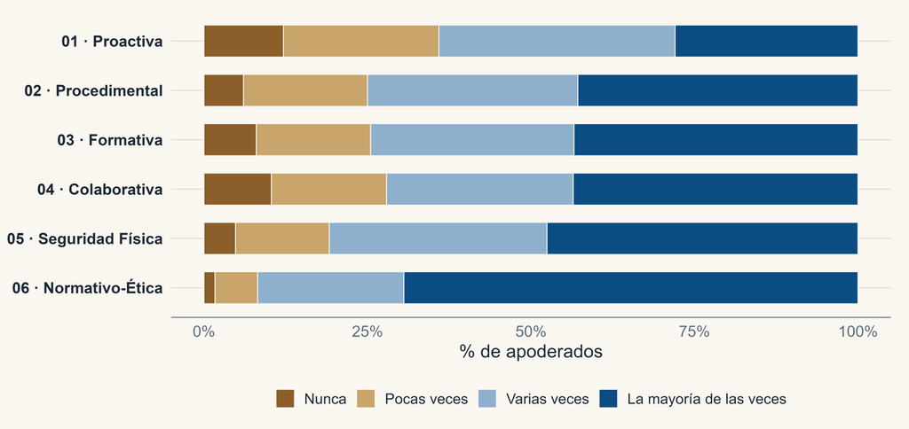

## 03 · Teoría Clásica de los Tests · Confiabilidad del instrumentoAnálisis de consistencia interna

Se calculó el coeficiente **Alfa de Cronbach** ($\alpha$) con el paquete `psych`, junto a las correlaciones ítem-total corregidas y el alfa si se elimina cada ítem. Se considera óptimo un $\alpha > 0.7$.

- Se usan solo casos completos: con omisiones, las covarianzas *pairwise* generan matrices no comparables entre confiabilidad y AFC.
- Con pérdida <10% y mecanismo aleatorio (MCAR), los casos completos son robustos (Little y Rubin, 2002).
- En $N > 170.000$, la pérdida de potencia al eliminar 3,63% es insignificante frente a la ganancia en precisión (Cohen, West y Aiken, 2003).

## Tabla 2 · Confiabilidad y discriminación

TCT · Confiabilidad

α ≈ 0.88  
consistencia interna global — supera ampliamente el umbral de 0,70

**Discriminación:** un ítem discrimina si distingue a quienes puntúan alto de quienes puntúan bajo en el test. El índice es la correlación entre el ítem y el puntaje total, $r_{i(t-i)}$, calculada **excluyendo el propio ítem** del total para evitar que se correlacione consigo mismo.

| Ítem eliminado | Corr. ítem-total | α sin el ítem |
| --- | --- | --- |
| 01 · Proactiva | 0.66 | 0.865 |
| 02 · Procedimental | 0.74 | 0.851 |
| 03 · Formativa | 0.68 | 0.861 |
| 04 · Colaborativa | 0.73 | 0.852 |
| 05 · Seguridad Física | 0.72 | 0.855 |
| 06 · Normativo-Ética | 0.62 | 0.872 |

Las correlaciones ítem-resto se ubican entre 0.62 y 0.74, muy por sobre el mínimo de 0,30 exigido para conservar un ítem (Nunnally y Bernstein, 1994). El mayor $\alpha$ sin el ítem es 0.872, frente al $\alpha$ global de 0.88: **ningún ítem conviene eliminarse** — cada uno aporta varianza verdadera al constructo.

## 04 · Análisis Factorial Confirmatorio · Evidencias de validezCuadro 3 · Cargas factoriales estandarizadas

AFC · Validez estructural

El **Análisis Factorial Confirmatorio** verifica si las 6 variables convergen en un único factor latente, evaluando cargas e índices de ajuste — la evidencia de **estructura interna** que exigen los Estándares AERA, APA y NCME (2014). Modelo de un solo factor, estimador **WLSMV** (correlaciones policóricas, robusto ante la asimetría de ítems ordinales).

| Ítem | Carga factorial (λ) |
| --- | --- |
| 01 · Proactiva | 0.781 |
| 02 · Procedimental | 0.846 |
| 03 · Formativa | 0.790 |
| 04 · Colaborativa | 0.843 |
| 05 · Seguridad Física | 0.848 |
| 06 · Normativo-Ética | 0.822 |

Ninguna carga factorial fue inferior a 0,60: el ítem es un excelente representante del constructo  
(Hair et al., 1998; Brown, 2015).

## Resultados · Ajuste global del modelo

AFC · Índices de ajuste

| Índice | Valor obtenido | Criterio de corte | Estado |
| --- | --- | --- | --- |
| CFI | 0.987 | > 0.95 (Excelente) | Ajuste óptimo del modelo latente. |
| TLI | 0.979 | > 0.90 (Aceptable) | Respalda la covariación unidimensional. |
| SRMR | 0.037 | < 0.08 (Bueno) | Residuos de covarianza mínimos. |
| RMSEA | 0.111 | < 0.06 (Óptimo) | Inflación espuria en tests breves (Kenny, 2015). |

Criterios de corte convencionales (Hu y Bentler, 1999).

A pesar de la distorsión matemática documentada del RMSEA en modelos de bajos grados de libertad (Kenny, Kaniskan y McCoach, 2015), la convergencia robusta de **CFI**, **TLI** y **SRMR** confirma la validez de constructo unidimensional del PGIP.

## 05 · Invarianza · Control por variables sociodemográficasTabla 3 · Por Grupo Socioeconómico y Dependencia

TCT AFC · Como aproximación a la **invarianza de medida**: Alfa (>0,80) y ajuste CFI/TLI (>0,95) · SRMR (<0,08)  
entre subgrupos.

| Categoria | N | TCT Media | TCT Alfa | AFC CFI | AFC TLI | AFC SRMR |
| --- | --- | --- | --- | --- | --- | --- |
| 1. Grupo Socioeconómico |  |  |  |  |  |  |
| Alto | 16426 | 3.25 | 0.872 | 0.983 | 0.972 | 0.048 |
| Bajo | 41088 | 3.16 | 0.883 | 0.988 | 0.980 | 0.036 |
| Medio | 39568 | 3.12 | 0.880 | 0.987 | 0.978 | 0.038 |
| Medio Alto | 17393 | 3.04 | 0.879 | 0.983 | 0.971 | 0.044 |
| Medio Bajo | 57322 | 3.16 | 0.882 | 0.988 | 0.980 | 0.036 |
| 2. Dependencia Administrativa |  |  |  |  |  |  |
| Municipal | 48018 | 3.13 | 0.884 | 0.988 | 0.980 | 0.035 |
| Particular pagado | 16570 | 3.25 | 0.871 | 0.983 | 0.971 | 0.048 |
| Particular subvencionado | 97184 | 3.15 | 0.880 | 0.987 | 0.979 | 0.038 |
| SLE | 10025 | 3.08 | 0.882 | 0.987 | 0.978 | 0.038 |

## Tabla 3 · Por Zona Geográfica y Orientación

| Categoria | N | TCT Media | TCT Alfa | AFC CFI | AFC TLI | AFC SRMR |
| --- | --- | --- | --- | --- | --- | --- |
| 3. Zona Geográfica |  |  |  |  |  |  |
| Rural | 5278 | 3.17 | 0.886 | 0.989 | 0.982 | 0.035 |
| Urbano | 166519 | 3.15 | 0.880 | 0.987 | 0.978 | 0.037 |
| 4. Orientación |  |  |  |  |  |  |
| Confesional/Religioso | 72475 | 3.20 | 0.880 | 0.988 | 0.980 | 0.036 |
| Laico | 96887 | 3.11 | 0.880 | 0.986 | 0.977 | 0.039 |

**Lectura:** el PGIP es confiable y estructuralmente válido en **todos** los estratos ($\alpha > 0.85$ · CFI > 0,98 · TLI > 0,97)  
Se descarta un Funcionamiento Diferencial del Ítem (DIF) estructural severo.  
*La estructura interna, sin embargo, no agota la validez: **a continuación** aportamos la evidencia basada en la **relación con otras variables**, la cuarta fuente de los Estándares.*

## 06 · Validez · Relación con otras variablesConvergencia y divergencia

Convergente · p12 · acciones antiviolencia Mismo constructo por otra vía (misma raíz) → se espera correlación **positiva y fuerte**  
(Campbell y Fiske, 1959).

Divergente · p13 · victimización del hijo(a) Constructo distinto (otra raíz) → se espera **negativa**. Es, además, la prueba del efecto halo.

[figure not shown]

**G** Gestión (PGIP) · **A** Antiviolencia · **V** Victimización — bloques azules convergen, bloques oro divergen (matriz multi-rasgo; Campbell y Fiske, 1959).

## Corrección por atenuación

Validez · Relación con otras variables

Toda medición conlleva error, y el error **atenúa** cada correlación observada. La corrección estima la relación entre los **valores verdaderos** (Spearman, 1904):

$$\rho_{t_X t_Y} = \frac{\rho_{XY}}{\sqrt{\rho_{XX'}}\,\sqrt{\rho_{YY'}}} \qquad\text{con el techo}\qquad \rho_{XY} \le \sqrt{\rho_{XX'}}\,\sqrt{\rho_{YY'}}$$

| Evidencia | Escala criterio (mismo cuestionario) | Predicción teórica | r observada | ρ criterio | r desatenuada |
| --- | --- | --- | --- | --- | --- |
| Convergente | Acciones antiviolencia · p12 (7 ítems) | Positiva y fuerte | 0.769 | 0.929 | 0.851 |
| Divergente | Victimización del hijo(a) · p13 (10 ítems) | Negativa, sin acoplarse | −0.310 | 0.888 | −0.351 |

Fiabilidad del PGIP en esta submuestra: ρ<sub>XX'</sub> = 0.880 · N = 163.473. La divergencia se corrige con la fiabilidad de su propia escala criterio.

**Lectura:** desatenuada, la **convergencia** es alta — el PGIP y la prevención antiviolencia miden esencialmente el mismo rasgo latente (el constructo *tiene entidad, no es espurio*). La **divergencia** es negativa pero se mantiene **muy por debajo del techo de −1**: los dos constructos verdaderos son distintos.

**El efecto halo, acotado:** un halo global habría acoplado gestión y victimización casi hasta el techo; que la divergencia real quede lejos de −1 muestra que el apoderado **distingue** «gestiona» de «lo molestan». En la revisión de sesgos, el halo pasa de *no identificable* a **acotado.**

## 07 · Del ítem al puntaje · Puntuación del constructo y resultadosJustificación psicométrica: modelo lineal de la TCT

TCT · Puntuación

La estimación del puntaje latente se fundamenta en el **Modelo Lineal de la TCT** (Crocker & Algina, 2008):

$$X = T + E \qquad\qquad X_{\text{total}} = \sum_{i=1}^{6} X_i = \sum_{i=1}^{6} T_i + \sum_{i=1}^{6} E_i$$

- **τ-equivalencia esencial:** el AFC mostró cargas factoriales intensas y homogéneas  
  ($\lambda$ entre 0,78 y 0,85) — los ítems miden el constructo con unidades métricas equivalentes.
- **Mitigación del error aleatorio:** al sumar linealmente los ítems, las varianzas de error se cancelan por agregación, maximizando la varianza verdadera del constructo global.

## Tabla 4 · Métrica escalar y distribución del PGIP (0–100)

TCT · Transformación

$$PGIP_{100} = \left( \frac{X_{\text{bruto}} - 6}{24 - 6} \right) \times 100$$

| PGIP | Media | DE | Mín. | Máx. |
| --- | --- | --- | --- | --- |
| Bruto (6–24) | 18.90 | 4.32 | 6.00 | 24.00 |
| Estandarizado (0–100) | 71.67 | 24.02 | 0.00 | 100.00 |

**Lectura:** la transformación es **lineal y continua**: cambia la regla del instrumento, no la forma de la distribución. La asimetría de los ítems reaparece a escala: masa en la parte alta, cola hacia los puntajes bajos.

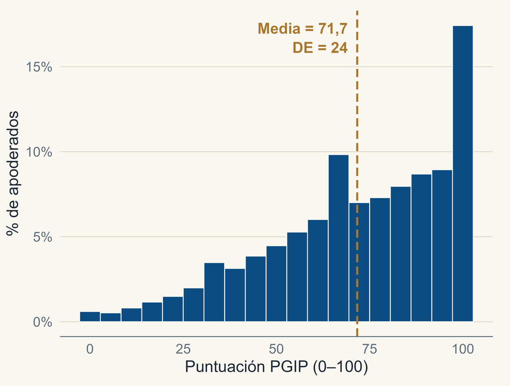

## Tabla 5 · Puntuaciones e incertidumbre

Reporte · IC 95%

| Categoria | N | Media | DE | IC 95% |
| --- | --- | --- | --- | --- |
| 1. Grupo Socioeconómico |  |  |  |  |
| Alto | 16426 | 75.00 | 22.34 | [74.66 ; 75.34] |
| Bajo | 41088 | 72.17 | 24.25 | [71.94 ; 72.40] |
| Medio | 39568 | 70.71 | 24.13 | [70.47 ; 70.95] |
| Medio Alto | 17393 | 68.03 | 24.27 | [67.67 ; 68.39] |
| Medio Bajo | 57322 | 72.12 | 23.99 | [71.92 ; 72.32] |
| 2. Dependencia Administrativa |  |  |  |  |
| Municipal | 48018 | 70.88 | 24.29 | [70.66 ; 71.10] |
| Particular pagado | 16570 | 74.83 | 22.47 | [74.49 ; 75.17] |
| Particular subvencionado | 97184 | 71.75 | 24.04 | [71.60 ; 71.90] |
| SLE | 10025 | 69.41 | 24.48 | [68.93 ; 69.89] |

| Categoria | N | Media | DE | IC 95% |
| --- | --- | --- | --- | --- |
| 3. Zona Geográfica |  |  |  |  |
| Rural | 5278 | 72.45 | 24.23 | [71.80 ; 73.10] |
| Urbano | 166519 | 71.64 | 24.01 | [71.52 ; 71.76] |
| 4. Orientación |  |  |  |  |
| Confesional/Religioso | 72475 | 73.23 | 23.53 | [73.06 ; 73.40] |
| Laico | 96887 | 70.47 | 24.31 | [70.32 ; 70.62] |

## Visualización de brechas por variables de control

El gráfico protagonista

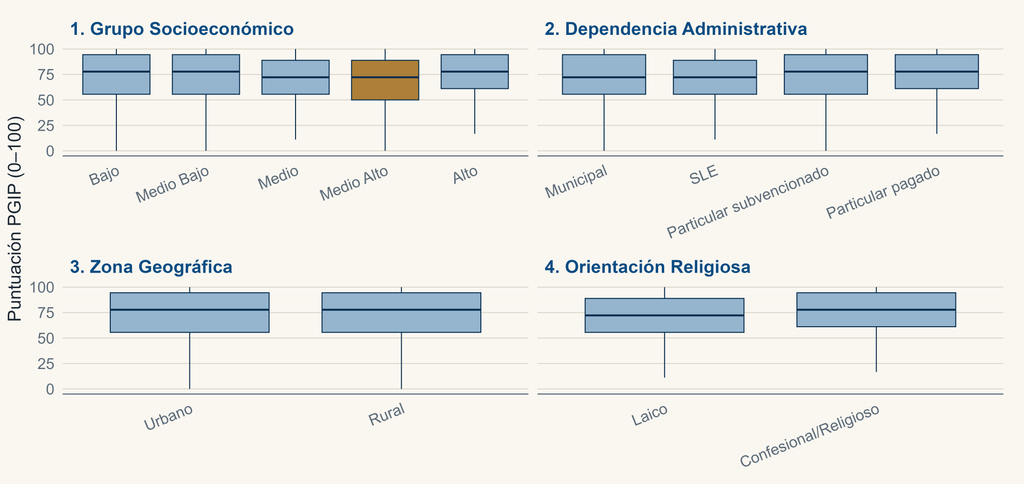

## Tabla 6 · Contraste de la hipótesis de brechas

Inferencia · Significancia y tamaño del efecto

Cierre inferencial de la **hipótesis descriptiva**: se contrasta el $PGIP_{100}$ medio entre los grupos de cada variable de control con la familia **Welch** — prueba *t* (2 grupos) y ANOVA (más de 2) — robusta a varianzas desiguales y opción por defecto de R; con $N = 171.797$, el TCL respalda la inferencia pese a la asimetría de la escala.

| Variable de control | Contraste | Estadístico | Valor p | Tamaño del efecto | Magnitud |
| --- | --- | --- | --- | --- | --- |
| 1. Grupo Socioeconómico | ANOVA de Welch | F(4; 60516) = 213.8 | < 0.001 | η² = 0.005 | Trivial |
| 2. Dependencia Administrativa | ANOVA de Welch | F(3; 33387) = 155.0 | < 0.001 | η² = 0.002 | Trivial |
| 3. Zona Geográfica | t de Welch | t(5610) = 2.38 | = 0.017 | d = 0.03 | Trivial |
| 4. Orientación Religiosa | t de Welch | t(158722) = 23.51 | < 0.001 | d = 0.11 | Trivial |

Umbrales de Cohen (1988): efecto pequeño desde d = 0,20 · η² = 0,01. Con dos grupos se reporta d; con más grupos se reporta η² (proporción de la varianza del PGIP explicada por la variable).

**Lectura:** las cuatro pruebas resultan **significativas** (p < 0,05): con esta potencia, hasta la brecha rural–urbana de 0,8 puntos rechaza H<sub>0</sub>. Pero **ningún efecto alcanza siquiera el umbral «pequeño» de Cohen** — la mayor brecha (GSE) explica apenas un 0,5% de la varianza.  
*La hipótesis se confirma en lo formal y se matiza en lo sustantivo: significancia estadística no es relevancia práctica.*

## 08 · Cierre · ConclusionesConclusiones psicométricas

Los resultados son consistentes con la **Hipótesis Psicométrica** planteada al inicio del estudio:

- **Validez de constructo unidimensional:** el AFC demostró que los 6 indicadores convergen sólidamente en un único factor latente, justificando el uso de la métrica $PGIP_{100}$.
- **Confiabilidad e invarianza robusta:** consistencia interna global excelente  
  ($\alpha \approx 0.88$); el test es equitativo para las 4 variables de control.
- **Refutación de sesgo por capital cultural:** el modelo no presentó caídas de ajuste en estratos Particulares Pagados o GSE Alto. Se descarta un DIF estructural.
- **Relación con otras variables:** el PGIP **converge** con la prevención antiviolencia y **diverge** de la victimización sin acoplarse — evidencia que **acota el efecto halo**.

## Conclusiones de brechas

- **La hipótesis de brechas se confirma solo en lo formal:** las cuatro pruebas de la Tabla 6 son significativas (p < 0,05), pero ningún tamaño de efecto alcanza el umbral «pequeño» de Cohen — las variables de control explican menos del 0,5% de la varianza del PGIP.
- **Brechas estructurales (GSE y Dependencia):** patrón no lineal — el grupo **Medio Alto** obtiene el puntaje más bajo de todos (68,0), por debajo incluso del GSE Bajo (72,2). Consistente con el sesgo de referencia: mayor capital cultural, estándares más exigentes.
- **El colegio como mesosistema protector:** la percepción es transversal a vulnerabilidad, territorio, religión y dependencia — en la práctica, las familias del país describen una misma gestión preventiva.

## Alcance y límites · Los once sesgos, revisados

Ningún diseño elimina los once sesgos declarados en el método. Con la evidencia ya presentada, cada uno queda **descartado por los datos**, **controlado en el preprocesamiento**, **acotado** por evidencia parcial, o **no identificable** con seis ítems de polaridad única y un solo informante.

[output not shown]

La escuela chilena logró *estandarizar* la gestión preventiva.

El desafío ahora es que esa estandarización formal se traduzca en una resolución real y eficaz del conflicto escolar cotidiano.